# Homework 1

### Exercise 13

The following plots four different transformations of the $\mathsf{Animals}$ data from the $\mathsf{MASS}$ package.  
What different aspects of the data do these different graphs emphasize?  
Consider the effect on low values of the variables, as contrasted with the effect on high values.

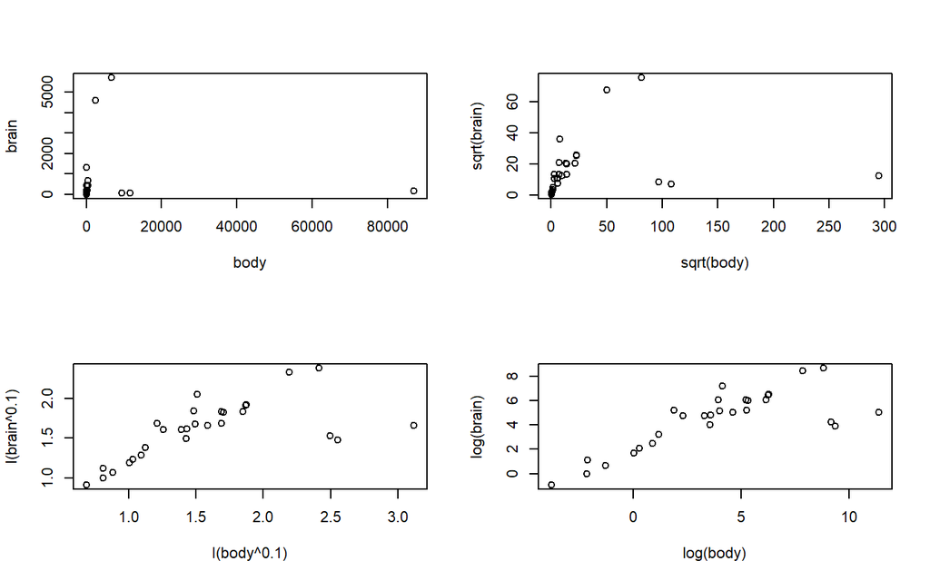

```r
par(mfrow=c(2,2)) # 2 by 2 layout on the page
library(MASS) # Animals is in the MASS package
plot(brain ~ body, data=Animals)
plot(sqrt(brain) ~ sqrt(body), data=Animals)
plot(I(brain^0.1) ~ I(body^0.1), data=Animals)
# I() forces its argument to be treated "as is"
plot(log(brain) ~ log(body), data=Animals)
```

```r
par(mfrow=c(1,1)) # Restore to 1 figure per page
```

**Solution**

These graphs emphasize the different relations between $\mathsf{brain}$ and $\mathsf{body}$, $\sqrt{\mathsf{brain}}$ and $\sqrt{\mathsf{body}}$, $\mathsf{brain^{0.1}}$ and $\mathsf{body^{0.1}}$, $\log({\mathsf{brain}})$ and $\log({\mathsf{body}})$.  
From the first two plots ($\mathsf{body}$ against $\mathsf{brain}$ and $\sqrt{\mathsf{body}}$ against $\sqrt{\mathsf{brain}}$) we can notice that most of the animals lie on the same region defined by the pair $\mathsf{(body,brain)}$, while there are few observations escaping this region.  
Instead, the other two plots ($\mathsf{body^{0.1}}$ against $\mathsf{brain^{0.1}}$ and $\log({\mathsf{body}})$ against $\log({\mathsf{brain}})$) show a positive correlation between these variables that was not visible in the first two plots where the variables take on high values and the scatterplot produces a line with a small slope (almost parallel to the $\mathsf{brain}$ axis).  
Therefore, the first two plots allow us to investigate possible outliers in the data while the other two show the correlation between the variables.

### Exercise 15

The data frame socsupport (DAAG) has data from a survey on social and other kinds of support, for a group of university students. It includes Beck Depression Inventory (BDI) scores. The following are two alternative plots of BDI against age:

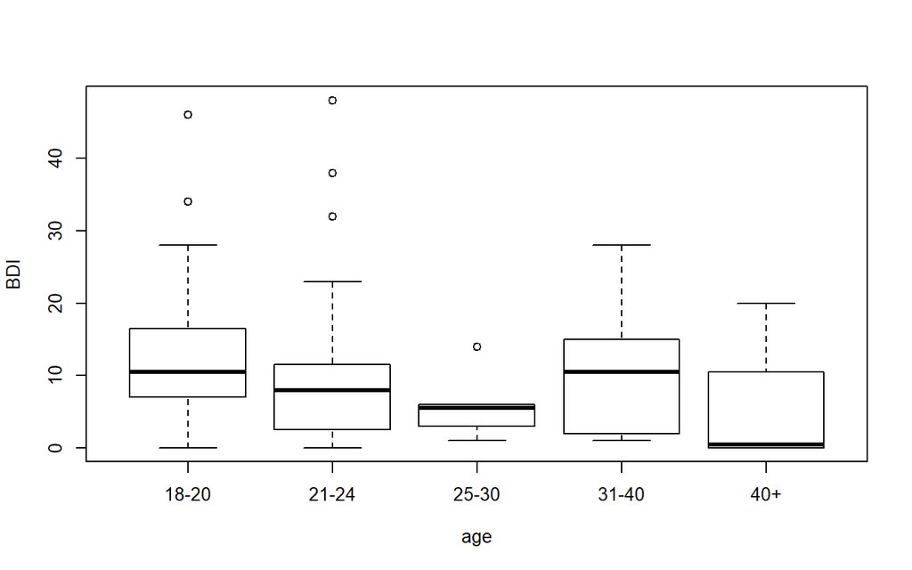

```r
library(DAAG)
plot(BDI ~ age, data=socsupport)
```

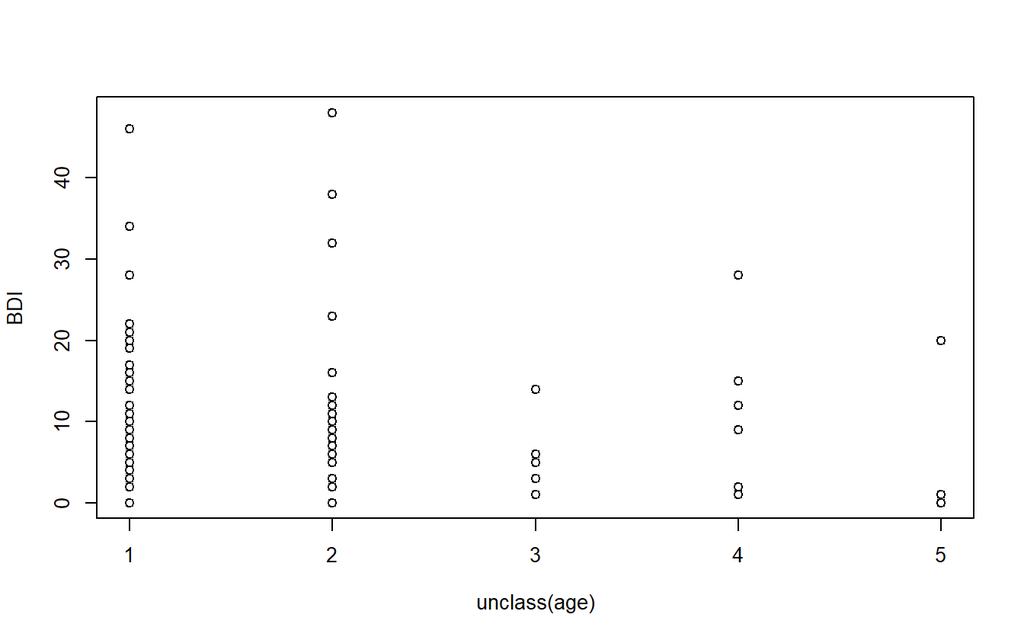

```r
plot(BDI ~ unclass(age), data=socsupport)
```

For examination of cases where the score seems very high, which plot is more useful? Explain. Why is it necessary to be cautious in making anything of the plots for students in the three oldest age categories (25-30, 31-40, 40+)?

**Solution**

The first plot is better in order to examine the high scores because it clearly shows the outliers for every age category thus allowing us to quickly decide whether to keep these data or not. Nevertheless, we need to be careful evaluating the three oldest age categories because, as we can see from the second plot, we don’t have a lot of data for those categories, hence we might draw wrong conclusion from our dataset just because of our small sample size, something that is impossible to evaluate in the boxplot plot.

### Exercise 17

Given a vector x, the following demonstrates alternative ways to create a vector of numbers from 1 through n, where n is the length of the vector:

```r
x <- c(8, 54, 534, 1630, 6611)
seq(1, length(x))
```

```
## [1] 1 2 3 4 5
```

```r
seq(along=(x))
```

```
## [1] 1 2 3 4 5
```

Now set x <- NULL and repeat each of the calculations seq(1, length(x)) and seq(along=x). Which version of the calculation should be used in order to return a vector of length 0 in the event that the supplied argument is NULL.

**Solution**

```r
x <- NULL
seq(1, length(x))
```

```
## [1] 1 0
```

```r
seq(along=(x))
```

```
## integer(0)
```

The first one (seq(1, length(x))) gives a vector of length 2, because it starts from 1 and ends at the length of x which is 0 in this case, so the given output will be a vector starts from 1 and ends at 0, so it is not the required vector of length 0.

The second one gives an (integer(0)), which is the way of printing a zero-length vector. And to test the length of that output, we can try length function :

```r
length(seq(along=(x)))
```

```
## [1] 0
```

### Exercise 20

The help page for iris (type help(iris)) gives code that converts the data in iris3 (datasets package) to case-by-variable format, with column names “Sepal.Length”, “Sepal.Width”, “Petal.Length”, “Petal.Width”, and “Species”. Look up the help pages for the functions that are used, and make sure that you understand them. Then add annotation to this code that explains each step in the computation.

**Solution**

```r
dni3 <- dimnames(iris3)
ii <- data.frame(matrix(aperm(iris3, c(1,3,2)), ncol = 4,
                        dimnames = list(NULL, sub(" L.",".Length",
                                                  sub(" W.",".Width", dni3[[2]])))),
                 Species = gl(3, 50, labels = sub("S", "s", sub("V", "v", dni3[[3]]))))
```

- dimnames: yields the names of the “columns” of each dimension"
- aperm: transposes an array by permuting its dimensions as indicated by c(1,3,2). In our case 1 is the id of the row, 2 addresses the Iris dimensions (Sepal Lenght, etc…), 3 is the Iris species.
- sub replaces the matched pattern (“W.”) with its replacement “.Width” in considered string
- matrix turns your data into a matrix
- list turns your data into a list
- data.frame: arranges the data into a dataframe
- gl: adds a factor, where 3 is the number of levels, 50 the number of rows with the same level. So in this case we will have 50 “Setosa”, 50 “Virginica”, 50 “Versicolora”

# Core Statistics

### Exercise 1.1

Exponential random variable, X ≥ 0, has p.d.f. f(x) = λ exp(−λx). 1. Find the c.d.f. and the quantile function for X. 2. Find Pr(X < λ) and the median of X. 3. Find the mean and variance of X.

**Solution**

#### CDF of Exponential distribution

We recall that the exponential distribution is defined as $f(x) = \lambda e^{-\lambda x}$ , with $x > 0$. Its CDF then is computed by:
$$F_X(x) = \int_0^x \lambda e^{-\lambda x} dx = - \int_0^x \frac{d}{dx} e^{-\lambda x} dx = 1 - e^{-\lambda x}$$

#### Quantile function

The quantile function is defined as $Q(p) = inf\{x \in \mathbb{R} : p \leq F(x) \}$

For the exponential distribution then we have
$$p = 1 - e^{-\lambda Q(p)} \Rightarrow Q(p) = \frac{ln(1-p)}{\lambda}$$
Then we can demonstrate also the following results:

- $Pr( x < \lambda ) = Pr( 0 \leq x < \lambda) = 1 - e^{-\lambda^2}$
- $Median = Q(\frac{1}{2}) = \frac{ln(\frac{1}{2})}{\lambda}$

#### Mean

$$\mathbb{E}(x) = \int_0^\infty x \lambda e^{-\lambda x} dx$$
By applying the integration by parts method, and multiplying and dividing $-\lambda$ on the second integral we obtain

$$\mathbb{E}[X] = \left| xe^{-\lambda x} \right|_0^\infty - \frac{1}{\lambda} \int_0^\infty -\lambda e^{-\lambda x} dx = - \frac{1}{\lambda} \left| e^{-\lambda x} \right|_0^\infty = \frac{1}{\lambda}$$

#### Variance

We will use the following formula in order to calculate the variance

$$\mathbb{V}[X] = \mathbb{E}[X^2] - (\mathbb{E}[X])^2$$

$$\mathbb{E}[X^2] = \int_0^\infty x^2 \lambda e^{-\lambda x} dx$$

By applying a similar technique used for the computation of the mean and reusing the last integral result we find that
$$\mathbb{E}[X^2] = \left| x^2 e^{-\lambda x} \right|_0^\infty + \int_0^\infty 2x e^{-\lambda x} dx = \frac{2}{\lambda} \int_0^\infty \lambda x e^{-\lambda x} dx = \frac{2}{\lambda^2}$$
Then
$$\mathbb{V}[X] = \mathbb{E}[X^2] - (\mathbb{E}[X])^2 = \frac{2}{\lambda^2} - \frac{1}{\lambda^2} = \frac{1}{\lambda^2}$$

### Exercise 1.2

**Solution**

The probability at the given interval is equal to the integral of joint distribution function at that interval :
$$Pr{(x,y\in \Omega}) = \iint_{\mathcal{\Omega}} f(x,y) dxdy$$
$$Pr(x<0.5, y<0.5)= \int_0^{0.5} \int_0^{0.5} x + 3 \frac{y^2}{2} dx dy$$

$$= \int_0^{0.5} \frac{x^2}{2}]_{0}^{0.5} + x]_{0}^{0.5}*3 \frac{y^2}{2} dy$$
$$= \int_0^{0.5} \frac{1}{8} + 3 \frac{y^2}{4} dy$$
$$= \frac{1}{8}*y ]_{0}^{0.5} + \frac{y^3}{4}]_{0}^{0.5}$$
$$= \frac{1}{16} + \frac{1}{32} = \frac{3}{32}$$

So, the $Pr(X < 0.5, Y < 0.5)$ = $\frac{3}{32}$

### Exercise 1.6

Let X and Y be non-independent random variables, such that : $var(X) = \sigma_x^2$ , $var(Y ) = \sigma_y2$ and $cov(X, Y ) = \sigma_xy^2$. Using the result from Section 1.6.2, find var(X + Y ) and var(X − Y ).

**Solution**

- Var(X+Y) :

let Z be a multivariate normal random vector, where : $Z = [X \quad Y]^T$ and let $a = [1 \quad 1]^T$ . Then, by the results of section 1.6.2 :
$$a^T Z \sim N(a^T\mu, a^T \Sigma a)$$

But $a^T Z = [1 \quad 1] [X \quad Y]^T = X+Y$. Then, $Var(a^T Z) = Var(X+Y) = a^T\Sigma a$

Where $\pmb{\Sigma} = \begin{bmatrix} \sigma_x^2 & \sigma_{xy}^2 \\\sigma_{xy}^2 & \sigma_y^2\end{bmatrix}$

$$Var(X+Y) = a^T\Sigma a$$
$$= [1 \quad 1] * \begin{bmatrix} \sigma_x^2 & \sigma_{xy}^2 \\\sigma_{xy}^2 & \sigma_y^2\end{bmatrix}* \begin{bmatrix} 1 \\1 \end{bmatrix}$$
$$= [(\sigma_x^2 + \sigma_{xy}^2) \quad (\sigma_{xy}^2+\sigma_y^2)] * \begin{bmatrix} 1 \\1 \end{bmatrix}$$
$$= \sigma_x^2 + \sigma_{xy}^2+ \sigma_{xy}^2+ \sigma_y^2$$
$$= Var(X) + 2 cov(x,y) + Var(Y)$$

- Var(X-Y) :

similarlly as Var(X+Y), but with a change in vector a : $a = [1 \quad -1]^T$.
$$Var(X-Y) = Var(a^TZ) = a^T\Sigma a$$
$$= [1 \quad -1] * \begin{bmatrix} \sigma_x^2 & \sigma_{xy}^2 \\\sigma_{xy}^2 & \sigma_y^2\end{bmatrix}* \begin{bmatrix} 1 \\-1 \end{bmatrix}$$
$$= [(\sigma_x^2 - \sigma_{xy}^2) \quad (\sigma_{xy}^2-\sigma_y^2)] * \begin{bmatrix} 1 \\-1 \end{bmatrix}$$
$$= \sigma_x^2 - \sigma_{xy}^2- \sigma_{xy}^2+ \sigma_y^2$$
$$= Var(X) - 2 cov(x,y) + Var(Y)$$

### Exercise 1.8

If $\log(\mathsf{X}) \sim \mathcal{N}(\mu,\sigma^{2})$, find the $\mathsf{pdf}$ of $\mathsf{X}$.

**Solution**

Let $\mathsf{z}=\log(\mathsf{x})$. We know that $f_{Z}\sim\mathcal{N}(\mu,\sigma^{2})=\frac{1}{\sqrt{2\pi}\sigma}e^{-\frac{(x-\mu)^2}{2\sigma^2}}$.
Let $x=g(z)=e^z$. Using the formula for the transformation of random variables, we have:
$$\begin{aligned}
f_{X}(x)&=f_{z}(g^{-1}(x))\bigg|\frac{dz}{dx}\bigg| \\
&=\frac{1}{\sqrt{2\pi}\sigma}e^{-\frac{(\log(x)-\mu)^2}{2\sigma^2}}\bigg|\frac{1}{x}\bigg|
\end{aligned}$$
Thus, the marginal of $\mathsf{x}$ is:
$$f_{X}(x)=\frac{1}{x\sqrt{2\pi}\sigma}e^-{\frac{(\log(x)-\mu)^2}{2\sigma^2}}, \ \ for \ x>0.$$

### Exercise 1.9

Discrete random variable $Y$ has a Poisson distribution with parameter $\lambda$ if its p.d.f. is $f(y)=\lambda^ye^{-\lambda y}/y!$, for $y=0, 1, ...$

1. Find the moment generation function for $Y$ (hint: the power series representation of the exponential function is useful).
2. If $Y_1 \sim \mathrm{Poi}(\lambda_1)$ and independently $Y_2 \sim \mathrm{Poi}(\lambda_2)$, deduce the distribution of $Y_1+Y_2$, by employing a general property of m.g.f.s.
3. Making use of the previous result and the central limit theorem, deduce the normal aproximation to the Poisson distribution.
4. Confirm the previous result grafically, using R functions $\mathsf{dpois}$, $\mathsf{dnorm}$, $\mathsf{plot}$, $\mathsf{barplot}$, $\mathsf{lines}$. Confirm that the aproximation improves increasing $\lambda$.

**Solution:**
a.
$$M_Y(s)=E(e^{sy})=e^{-\lambda} \sum_{y=0}^{\infty} \frac{1}{y!}e^{sy}\lambda^y
= e^{-\lambda} \sum_{y=0}^{\infty} \frac{1}{y!} \left( e^{s}\lambda \right)^y
= e^{-\lambda} e^{\lambda e^{s}} = e^{\lambda (e^s-1)}$$
b. The most useful property of the m.g.f. in this case is the one of the independence: $M_{X+Y}=M_X M_Y$ for $X$ and $Y$ independent.

$$M_{Y_1+Y_2}(s) = M_{Y_1}(s) M_{Y_2}(s) = e^{\lambda_1 \left( e^s-1 \right)} e^{\lambda_2 \left( e^s-1 \right)} =
e^{\left( \lambda_1 + \lambda_2\right) \left( e^s-1 \right)}
\equiv e^{\lambda' \left( e^s-1 \right)}$$

As m.g.f determines univocally a distribution, it implies that $X+Y \sim \mathrm{Pois}(\lambda' = \lambda_1 + \lambda_2)$.

c. Let suppose $n$ independent and equal variables $X_1, X_2,...,X_i,...,X_n$ with $X_i \sim \mathrm{Pois}(\lambda)$. As seen previously, the sum must be distributed by another Poisson: $Y=\sum_i X_i \sim \mathrm{Pois}(n \lambda)$. Because of the c.l.t., is known that the sum of identycal Poissons, which is another Poisson as seen, must be distributed like: $Y=\sum_i X_i \sim \cal{N}(\mu,\sigma^2)$ being $\mu=\left<Y\right>$ and $\sigma=\mathrm{var}(Y)$. As distribution $Y$ is also a Poisson, it follows that $\mu=n\lambda$ and $\sigma=n\lambda$, so the aproximated normal comes like $\cal{N}(n\lambda,n\lambda)$. One of the conditions of the c.l.t. is $n \to \infty$, so the term $n\lambda$ can be interpreted like $n\lambda=\lambda' \to \infty$. The result is that a single Poisson distribution $Y=\mathrm{Pois}(\lambda')$ aproximates to a normal when $\lambda'$ is enough large:

$$\mathrm{Pois}(\lambda') \approx \cal{N}(\lambda',\lambda'); \ \lambda' \to \infty$$
d.

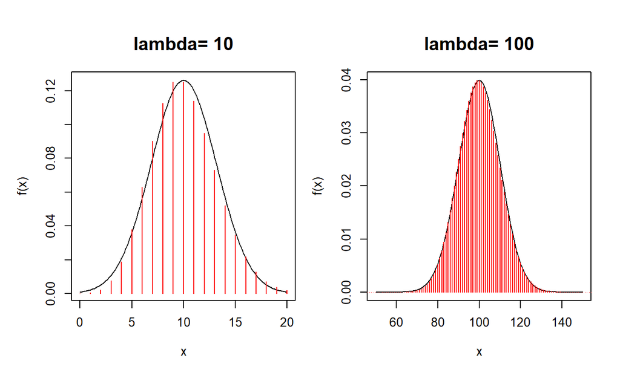

```r
#parameters
par(mfrow=c(1,2), mar=c(5,4,4,1), oma=c(1,1,1,1))
p<-0.5; lambda1<-10; lambda2<-100; n<-200

#normal approximation
prob_bin <- dpois(0:n, lambda1)
curve(dnorm(x, lambda1, sqrt(lambda1)), xlim=c(0,2*lambda1),
      xlab="x", ylab="f(x)",
      main=paste("lambda=", lambda1), cex.main=1.5)
lines(0:n,prob_bin, type="h", main="lambda=10", xlim=c(0,2*lambda1),
      cex.lab=1.5, col="red")

#plot
prob_bin <- dpois(0:n, lambda2)
curve(dnorm(x, lambda2, sqrt(lambda2)), xlim=c(lambda2-lambda2/2,lambda2+lambda2/2),
      xlab="x", ylab="f(x)",
      main=paste("lambda=", lambda2), cex.main=1.5)
lines(0:n,prob_bin, type="h", main="lambda=100", xlim=c(lambda2-lambda2/2,lambda2+lambda2/2),
      cex.lab=1.5, col="red")
```